# THE MATHEMATICS GENDER GAP

## Effects On Student/Parent's Attitude

## Towards Mathematics On Overall Score

### INVESTIGATION OVERVIEW

In this investigation, I wanted to take a closer a look at what attitudes of both the students and parents that contributed to overall PISA score's gender gap. The main focus was gender, different kinds of attitudes of students towards math (motivation, anxiety, interest, work ethic, behavior) as well as the the student's perception on how their parent's view math.

### DATASET OVERVIEW

The original PISA 2012 dataset contained information from 485,490 students and 646 features. After our data cleaning process, we condensed the number of features to 10: country, gender, overall math score, motivation score, anxiety score, interest score, work ethic score, behavior score, and parent's attitude towards math score. All features under attitude (with the exception of anxiety) have a scale of 4 points, marking highest positive attitude, to 1 point, marking a negative attitude. Anxiety works conversly, where 1 points shows a student to be less anxious (positive attitude) and 4 points being really anxious towards math (negative attitude).

### DISTRIBUTION OF OVERALL MATH SCORE

The overall math scores are normally distributed with a mean around 469 points. The math scores range from the lowest being 19.8 points to the highest, which was 962.2 points.

[figure not shown]

### DISTRIBUTION OF ATTITUDE SCORES BY GENDER

If we take a look at the distribution of high scores in the category of motivation, interest, behavior and self, the male students outweight the females students. But if we take a look at the high scores when it comes to anxiety and work ethic, the females students seem to score higher than the male students.

[figure not shown]

### GENDER PROPORTATION BY TOP PERCENTILE STUDENTS

We can see clearly here that as the top percentile increases, so does the gender gap. Initially, the female proportion was higher (due to the fact that there was a slightly more female students taking the survey as compared to the male students). But by the time we arrived to the top (approximately) 20th percentile, the amount of female students was equal to the amount of male students. All throughout the increase of top percentiles, we see that the proportion of male students strictly increases as well. Notice that the further we get along the top percentile of students, the gender gap's increase accelerates.

```python
import numpy as np
import pandas as pd
import matplotlib.pyplot as plt
import seaborn as sb

%matplotlib inline

plt.style.use('fivethirtyeight')
```

```python
df=pd.read_csv('top_percent.csv')
```

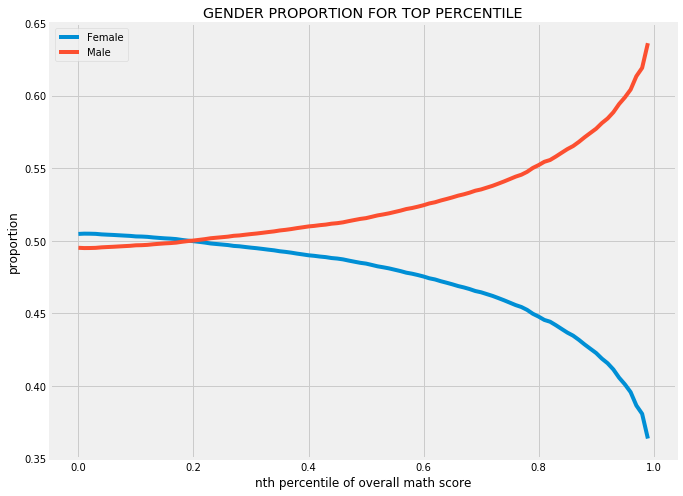

```python
plt.figure(figsize=(10,8))
sb.lineplot(data=df,x='nth_percentile',y='f_prop', label='Female')
sb.lineplot(data=df,x='nth_percentile',y='m_prop',label='Male')
plt.legend()
plt.title('GENDER PROPORTION FOR TOP PERCENTILE')
plt.ylabel('proportion')
plt.xlabel('nth percentile of overall math score');
```

### MOTIVATION SCORES BY TOP PERCENTILE STUDENTS BY GENDER

**The average motivation score for males is consistently higher that the average motivation score for females.**

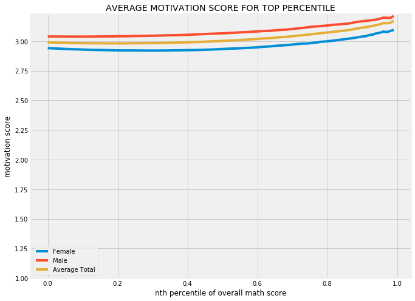

```python
plt.figure(figsize=(10,8))
sb.lineplot(data=df,x='nth_percentile',y='f_motivation', label='Female')
sb.lineplot(data=df,x='nth_percentile',y='m_motivation', label='Male')
sb.lineplot(data=df,x='nth_percentile',y='avg_motivation', label='Average Total')
plt.legend()
plt.title('AVERAGE MOTIVATION SCORE FOR TOP PERCENTILE')
plt.ylim(bottom=1)
plt.ylabel('motivation score')
plt.xlabel('nth percentile of overall math score');
```

### ANXIETY SCORES BY TOP PERCENTILE STUDENTS BY GENDER

**The average anxiety score for females is consistently higher than the average anxiety score for males. As the top percentile increases, the anxiety scores for both gender decreases.**

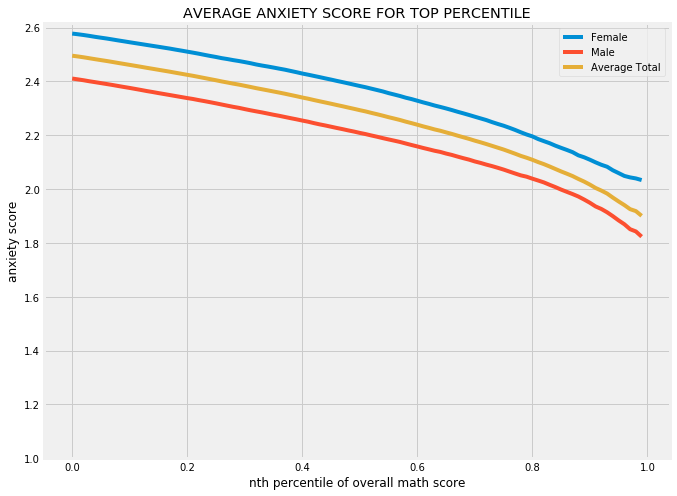

```python
plt.figure(figsize=(10,8))
sb.lineplot(data=df,x='nth_percentile',y='f_anxiety', label='Female')
sb.lineplot(data=df,x='nth_percentile',y='m_anxiety', label='Male')
sb.lineplot(data=df,x='nth_percentile',y='avg_anxiety', label='Average Total')
plt.legend()
plt.title('AVERAGE ANXIETY SCORE FOR TOP PERCENTILE')
plt.ylim(bottom=1)
plt.ylabel('anxiety score')
plt.xlabel('nth percentile of overall math score');
```

### INTEREST SCORES BY TOP PERCENTILE STUDENTS BY GENDER

**The average interest score for males is consistently higher that the average interest score for females.**

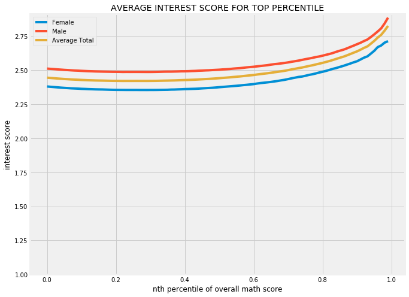

```python
plt.figure(figsize=(10,8))
sb.lineplot(data=df,x='nth_percentile',y='f_interest', label='Female')
sb.lineplot(data=df,x='nth_percentile',y='m_interest', label='Male')
sb.lineplot(data=df,x='nth_percentile',y='avg_interest', label='Average Total')
plt.legend()
plt.title('AVERAGE INTEREST SCORE FOR TOP PERCENTILE')
plt.ylim(bottom=1)
plt.ylabel('interest score')
plt.xlabel('nth percentile of overall math score');
```

### WORK ETHIC SCORES BY TOP PERCENTILE STUDENTS BY GENDER

**The average work ethic score for females is consistently higher that the average work score for males.**

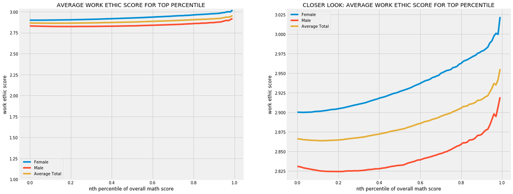

```python
plt.figure(figsize=(20,8))

plt.subplot(1,2,1)
sb.lineplot(data=df,x='nth_percentile',y='f_work_ethic', label='Female')
sb.lineplot(data=df,x='nth_percentile',y='m_work_ethic', label='Male')
sb.lineplot(data=df,x='nth_percentile',y='avg_work_ethic', label='Average Total')
plt.legend()
plt.title('AVERAGE WORK ETHIC SCORE FOR TOP PERCENTILE')
plt.ylim(bottom=1)
plt.ylabel('work ethic score')
plt.xlabel('nth percentile of overall math score')

plt.subplot(1,2,2)
sb.lineplot(data=df,x='nth_percentile',y='f_work_ethic', label='Female')
sb.lineplot(data=df,x='nth_percentile',y='m_work_ethic', label='Male')
sb.lineplot(data=df,x='nth_percentile',y='avg_work_ethic', label='Average Total')
plt.legend()
plt.title('CLOSER LOOK: AVERAGE WORK ETHIC SCORE FOR TOP PERCENTILE')
plt.ylabel('work ethic score')
plt.xlabel('nth percentile of overall math score');
```

### PARENT SCORES BY TOP PERCENTILE STUDENTS BY GENDER

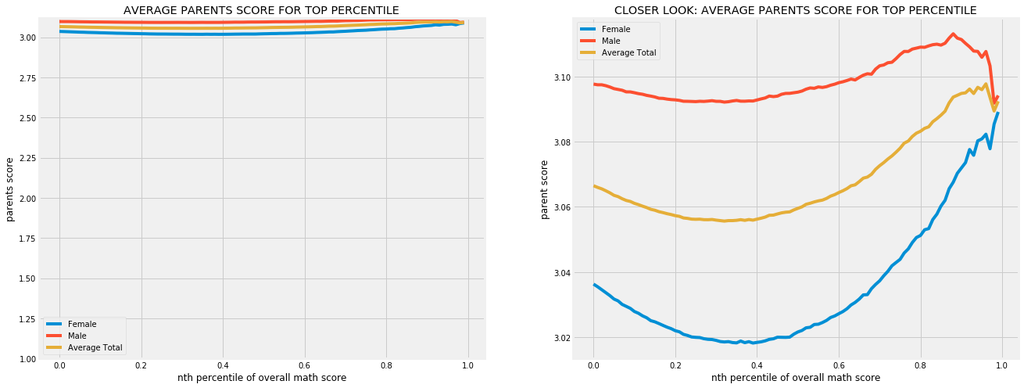

```python
plt.figure(figsize=(20,8))

plt.subplot(1,2,1)
sb.lineplot(data=df,x='nth_percentile',y='f_parents', label='Female')
sb.lineplot(data=df,x='nth_percentile',y='m_parents', label='Male')
sb.lineplot(data=df,x='nth_percentile',y='avg_parents', label='Average Total')
plt.legend()
plt.title('AVERAGE PARENTS SCORE FOR TOP PERCENTILE')
plt.ylim(bottom=1)
plt.ylabel('parents score')
plt.xlabel('nth percentile of overall math score')

plt.subplot(1,2,2)
sb.lineplot(data=df,x='nth_percentile',y='f_parents', label='Female')
sb.lineplot(data=df,x='nth_percentile',y='m_parents', label='Male')
sb.lineplot(data=df,x='nth_percentile',y='avg_parents', label='Average Total')
plt.legend()
plt.title('CLOSER LOOK: AVERAGE PARENTS SCORE FOR TOP PERCENTILE')
plt.ylabel('parent score')
plt.xlabel('nth percentile of overall math score');
```

### BEHAVIOR SCORES BY TOP PERCENTILE STUDENTS BY GENDER

**The average behavior score for males is consistently higher that the average behavior score for females.**

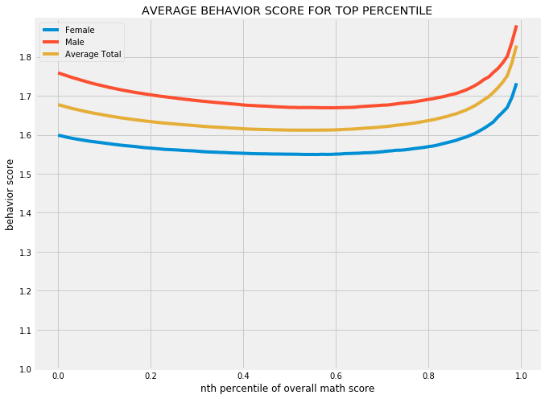

```python
plt.figure(figsize=(10,8))
sb.lineplot(data=df,x='nth_percentile',y='f_behavior', label='Female')
sb.lineplot(data=df,x='nth_percentile',y='m_behavior', label='Male')
sb.lineplot(data=df,x='nth_percentile',y='avg_behavior', label='Average Total')
plt.legend()
plt.title('AVERAGE BEHAVIOR SCORE FOR TOP PERCENTILE')
plt.ylim(bottom=1)
plt.ylabel('behavior score')
plt.xlabel('nth percentile of overall math score');
```

[figure not shown]

```python
plt.figure(figsize=(10,8))
sb.lineplot(data=df,x='nth_percentile',y='f_self', label='Female')
sb.lineplot(data=df,x='nth_percentile',y='m_self', label='Male')
sb.lineplot(data=df,x='nth_percentile',y='avg_self', label='Average Total')
plt.legend()
plt.title('AVERAGE SELF SCORE FOR TOP PERCENTILE')
plt.ylim(bottom=1)
plt.ylabel('self score')
plt.xlabel('nth percentile of overall math score');
```